# Getting A Step Ahead: Using the Regulararised Horseshoe Prior (RHSP) to Select Cross-Loadings in Bayesian Regularized SEM

3/26/2022

## The Art of Statistical Modeling

[figure not shown]

## Fundamental Trade-off in Statistical Modeling

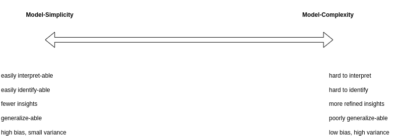

## Simple Structure: Simply not the best (Solution for a Complicated Issue)

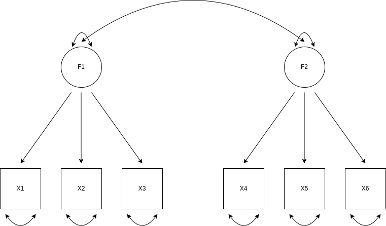

## Simple Structure: Simply not the best (solution for a complicated issue)

[figure not shown]

## Small Variance Normal Prior (SVNP): a better Solution for a Complicated Issue

- Don’t just assume that cross-loadings are zero ( \(\mathcal{N}(0, 0)\) )
- Instead make a more realistic and flexible assumption (Muthen and Asparouhov 2012):
  - Small Variance Prior, e.g.: \(\mathcal{N}(0, 0.01)\)
  - allowing for a more flexible model identification and model selection

## Small Variance Normal Prior (SVNP): Still no ideal Solution for a Complicated Issue

- Also (relevant) cross-loadings far from zero are shrunken (Lu, Chow, and Loken 2016)
- Consequently other parameters in the model (e.g. the factor-correlation, main-loadings) end up substantially biased too
- As solution, a two-step procedure is required, which is cumbersome and introduces a number of researchers degrees of freedom

*→* More advanced priors need to be identified that can outperform the small-variance prior *in a single step*

## The present study

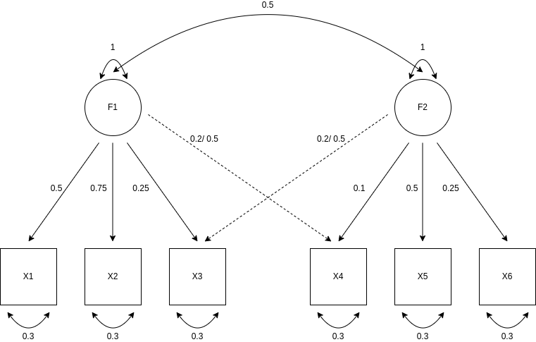

## The present study

- Monte Carlo Simulation using `stan` (Stan Development Team 2021)
- Population conditions:
  - N: 100, 200
  - magnitude cross-loading: 0.2, 0.5
- Prior conditions:
  - \(\sigma^2\): 0.1, 0.01, 0.001 (Muthen and Asparouhov 2012)
- Sampling parameters:
  - burnin 2000, chain length 4000
- 200 iterations per individual set of conditions
- Main outcomes: (mean absolute) bias, MSE, Power, Type I error rate
  - different selection rules regarding the latter two: tresholds, credible intervals (Zhang, Pan, and Ip 2021)

## Foreshadowing Thesis

- same population conditions as above
- RHSP hyper-parameter conditions:
  - scale of global shrinkage parameter: 0.1, 1
  - df of global shrinkage parameter: 1, 3
  - scale of local shrinkage parameter: 0.1, 1
  - df of local shrinkage parameter: 1, 3
  - df of slab: 1, 3

## Check out my work on Github

[Feel free to check out, criticize and improve my work!](https://www.github.com/JMBKoch/1vs2StepBayesianRegSEM)

[figure not shown]

## References

Carvalho, Carlos M., Nicholas G. Polson, and James G. Scott. 2010. “The Horseshoe Estimator for Sparse Signals.” *Biometrika* 97 (2): 465–80. https://doi.org/10.1093/biomet/asq017.

Ghosh, Joyee, Yingbo Li, and Robin Mitra. 2018. “On the Use of Cauchy Prior Distributions for Bayesian Logistic Regression.” *Bayesian Analysis* 13 (2): 359–83. https://doi.org/10.1214/17-BA1051.

Lu, Zhao-Hua, Sy-Miin Chow, and Eric Loken. 2016. “Bayesian Factor Analysis as a Variable- Selection Problem: Alternative Priors and Consequences.” *Multivariate Behavioral Research* 51 (4): 519–39. https://doi.org/10.1080/00273171.2016.1168279.

Muthen, Bengt, and Tihomir Asparouhov. 2012. “Bayesian SEM: A More FLexible Representation of Substantive Theory,” 78. https://doi.org/10.1037/a0026802.

Piironen, Juho, and Aki Vehtari. 2017. “Sparsity Information and Regularization in the Horseshoe and Other Shrinkage Priors.” *Electronic Journal of Statistics* 11 (2): 5018–51. https://doi.org/10.1214/17-EJS1337SI.

Stan Development Team. 2021. “Stan User Guide.” https://mc-stan.org/docs/2_27/stan-users-guide-2_27.pdf.

Zhang, Lijin, Junhao Pan, and Edward Haksing Ip. 2021. “Criteria for Parameter Identification in Bayesian Lasso Methods for Covariance Analysis: Comparing Rules for Thresholding, *p* -Value, and Credible Interval.” *Structural Equation Modeling: A Multidisciplinary Journal*, August, 1–10. https://doi.org/10.1080/10705511.2021.1945456.